# High-Dimensional Regression

### §6.4 Contrasting prediction-risk and support-recovery

The two main theorems of §§5–6 differ on every axis:

|  | Prediction-risk bound (§5) | Support-recovery bound (§6) |
| --- | --- | --- |
| **What's bounded** | $\frac{1}{n}\\|\mathbf{X}(\hat{\boldsymbol\beta} - \boldsymbol\beta^*)\\|_2^2$ | $\mathbb{P}(\mathrm{sign}(\hat{\boldsymbol\beta}) = \mathrm{sign}(\boldsymbol\beta^*))$ |
| **Sufficient design condition** | Restricted-eigenvalue (§5.4) | Irrepresentable (§6.2) |
| **Necessary?** | RE essentially necessary at the optimal rate | Strong IC necessary for *lasso* sign-consistency |
| **Sample-size scaling** | $n \gtrsim s \log(p)$ | $n \gtrsim s \log(p)$ |
| **Minimum-signal needed?** | No | Yes — $\beta^*_{\min} \gtrsim \lambda$ required |
| **Failure mode** | Larger $n$ helps (better RE) | Lasso fundamentally can't recover; need adaptive lasso (§8.3) or post-selection refit |

**The conditions are not nested.** RE doesn't imply IC, and IC doesn't imply RE. They measure different geometric properties: RE is a lower bound on $\mathbf{X}^\top \mathbf{X}/n$ restricted to a cone (a global property, doesn't depend on which $S$ is the active set); IC depends on $S$ and $\mathbf{s}^*_S$ specifically.

**Practical implications.** The lasso is a much better prediction tool than a model-selection tool.

- **For prediction:** trust the lasso. CV-selected $\lambda$, refit at $\lambda_{\text{CV}}$ or $\lambda_{1\mathrm{SE}}$. The §5 oracle inequality gives near-optimal prediction risk under mild conditions.
- **For variable selection:** be skeptical of the lasso's chosen support. Watch for (i) two highly correlated features where only one shows up — the lasso may have arbitrarily picked one — and (ii) the lasso fit changing dramatically across resampled training sets — instability suggests IC is violated. Use stability selection (Meinshausen-Bühlmann 2010) or the **adaptive lasso** (§8.3) for sign-consistency under weaker conditions.

## §7. Cross-validation for $\lambda$

The §5 oracle inequality recommends $\lambda \asymp \sigma \sqrt{\log(p)/n}$ — a rate, not a constant. The constant matters in practice, and the noise scale $\sigma$ is rarely known. Practical $\lambda$-selection uses data-driven criteria: **cross-validation** (the default), the **one-standard-error rule** (a parsimony-favoring variant), and **information criteria** like AIC/BIC computed along the lasso path. This section covers all three.

### §7.1 $K$-fold cross-validation with `LassoCV`

$K$-fold CV estimates the prediction risk at each $\lambda$ by holdout:

1. Partition training data into $K$ folds.
2. For each fold $k$ and each $\lambda$, fit the lasso on the data minus fold $k$, compute held-out MSE on fold $k$.
3. Average: $\mathrm{CV}(\lambda) = (1/K) \sum_k \mathrm{MSE}_k(\lambda)$.
4. Select $\lambda_{\min} = \arg\min_\lambda \mathrm{CV}(\lambda)$.

**Standard choices:** $K = 10$ for general use, $K = 5$ if compute is constrained, leave-one-out only when $n$ is small. The $\lambda$-grid is typically log-spaced from $\lambda_{\max}$ down to $\lambda_{\max} \cdot 10^{-3}$ with ~100 grid points.

**Computational efficiency.** Naively $K \times |\Lambda|$ lasso fits, but warm starts along the $\lambda$ path (recall §3.2) reduce this to ~$K$ path computations. For DGP-1 with $K=10$, $|\Lambda|=100$, $p=500$: ~1–3 seconds total.

### §7.2 The one-standard-error rule

The CV estimate is itself random. The **fold-wise standard error** $\mathrm{SE}(\lambda) := \mathrm{sd}_k(\mathrm{MSE}_k(\lambda)) / \sqrt{K}$ quantifies its uncertainty. The **one-standard-error rule** (Breiman et al. 1984; ESL §7.10) selects the most parsimonious model whose CV error is within one SE of the minimum:

$$ \lambda_{1\mathrm{SE}} := \max\{\lambda : \mathrm{CV}(\lambda) \le \mathrm{CV}(\lambda_{\min}) + \mathrm{SE}(\lambda_{\min})\}. $$

Since $\mathrm{CV}(\lambda)$ is roughly U-shaped, $\lambda_{1\mathrm{SE}} > \lambda_{\min}$ — the 1-SE model is more regularized, sparser.

**Caveat.** The 1-SE rule is a heuristic, not a theorem — no provable support consistency, no provable prediction-risk improvement. If you need either, use BIC (§7.3) or the §5 oracle inequality directly.

```
LassoCV (10-fold) on §1 DGP:
  lambda_min  = 0.0559  (CV MSE = 0.3438 +/- 0.0268)
  lambda_1SE  = 0.1047  (CV MSE = 0.3667)
  ratio lambda_1SE / lambda_min = 1.87
```

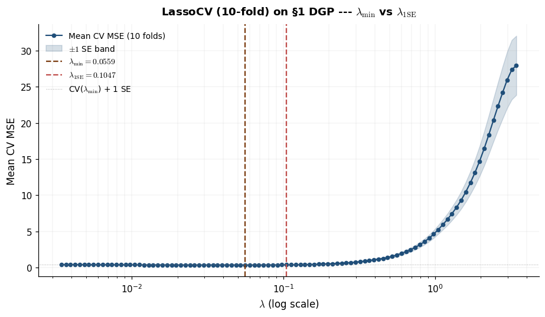

```python
# §7.2 — Figure 7.1: LassoCV curve with lambda_min and lambda_1SE markers.
# Use the §1 sample. Reuse the LassoCV fit from §1.4 (lasso_cv) — it already has
# the path stored in mse_path_, alphas_.

# (Re-fit here with cv=10 and store internals for the figure.)
fit_cv_10 = LassoCV(cv=10, fit_intercept=False, alphas=100,
                     random_state=SEED, max_iter=20_000).fit(X1, y1)
alphas_cv = fit_cv_10.alphas_                           # decreasing
mse_path  = fit_cv_10.mse_path_                          # (n_alphas, n_folds)
mse_mean  = mse_path.mean(axis=1)
mse_se    = mse_path.std(axis=1, ddof=1) / np.sqrt(mse_path.shape[1])

# lambda_min (= fit_cv_10.alpha_).
idx_min = int(np.argmin(mse_mean))
lam_min_cv = float(alphas_cv[idx_min])

# lambda_1SE: largest lambda with mse_mean <= mse_mean[idx_min] + mse_se[idx_min].
# Since alphas_cv is decreasing, "larger lambda" = smaller index.
threshold = mse_mean[idx_min] + mse_se[idx_min]
candidates = np.where(mse_mean[:idx_min + 1] <= threshold)[0]
idx_1se = int(candidates[0])
lam_1se = float(alphas_cv[idx_1se])

print(f"LassoCV (10-fold) on §1 DGP:")
print(f"  lambda_min  = {lam_min_cv:.4f}  (CV MSE = {mse_mean[idx_min]:.4f} +/- {mse_se[idx_min]:.4f})")
print(f"  lambda_1SE  = {lam_1se:.4f}  (CV MSE = {mse_mean[idx_1se]:.4f})")
print(f"  ratio lambda_1SE / lambda_min = {lam_1se / lam_min_cv:.2f}")

# Sanity: lambda_1SE >= lambda_min, and CV MSE at lambda_1SE <= threshold.
assert lam_1se >= lam_min_cv, "1-SE lambda should be >= minimum-CV lambda"
assert mse_mean[idx_1se] <= threshold + 1e-10, "1-SE lambda should satisfy threshold"

# --- Figure 7.1 ---
fig, ax = plt.subplots(figsize=(8.5, 5.0))
ax.plot(alphas_cv, mse_mean, "o-", color=COLOR_LASSO, linewidth=1.4, markersize=4,
        label="Mean CV MSE (10 folds)")
ax.fill_between(alphas_cv, mse_mean - mse_se, mse_mean + mse_se,
                color=COLOR_LASSO, alpha=0.18, label=r"$\pm 1$ SE band")
ax.axvline(lam_min_cv, color=COLOR_RIDGE, linewidth=1.5, linestyle="--",
           label=fr"$\lambda_{{\min}} = {lam_min_cv:.4f}$")
ax.axvline(lam_1se, color=COLOR_DEBIASED, linewidth=1.5, linestyle="--",
           label=fr"$\lambda_{{1\mathrm{{SE}}}} = {lam_1se:.4f}$")
ax.axhline(threshold, color="#888888", linewidth=0.7, linestyle=":",
           alpha=0.7, label=r"CV($\lambda_{\min}$) + 1 SE")
ax.set_xscale("log")
ax.set_xlabel(r"$\lambda$ (log scale)")
ax.set_ylabel("Mean CV MSE")
ax.set_title(r"LassoCV (10-fold) on §1 DGP --- $\lambda_{\min}$ vs $\lambda_{1\mathrm{SE}}$")
ax.legend(loc="upper left", fontsize=9)
ax.grid(True, which="both", linewidth=0.3, alpha=0.4)
fig.tight_layout()
fig.savefig(OUT_DIR / "fig_07_01_cv_curve.png", bbox_inches="tight")
plt.show()
```

### §7.3 BIC selection with `LassoLarsIC`

Information criteria balance model fit against complexity through an explicit complexity penalty. For a candidate $\lambda$ with active-set size $k_\lambda := |\hat A_\lambda|$ and residual sum of squares $\mathrm{RSS}_\lambda$:

$$ \mathrm{AIC}(\lambda) = n \log(\mathrm{RSS}_\lambda / n) + 2 k_\lambda, $$

$$ \mathrm{BIC}(\lambda) = n \log(\mathrm{RSS}_\lambda / n) + k_\lambda \log n. $$

Using $k_\lambda = |\hat A_\lambda|$ as the lasso's effective dof rests on **Zou-Hastie-Tibshirani (2007)**: the size of the active set is an unbiased estimator of the lasso's degrees of freedom, $\mathbb{E}[k_\lambda] = \mathrm{df}(\hat{\boldsymbol\beta}^{\text{lasso}}(\lambda))$. This is non-trivial; for a generic non-linear estimator, dof is not the count of nonzero parameters.

**`LassoLarsIC`.** Computes the lasso path via LARS (Efron-Hastie-Johnstone-Tibshirani 2004) — exploits piecewise linearity to enumerate every knot in $O(np \min(n, p))$. IC values computed at each knot; the minimizing $\lambda$ is returned. Path-based and exact (no $\lambda$-grid discretization), but only practical for moderate $p$.

**Selection consistency.** BIC is **selection-consistent** under additional conditions: $\mathbb{P}(\hat A_{\lambda_{\mathrm{BIC}}} = S) \to 1$ as $n \to \infty$ given a slightly stronger condition than IC and a bounded-below minimum signal (Wang-Li-Tsai 2009). AIC and CV are not — they tend to over-select even asymptotically. For variable-selection applications, this is BIC's main virtue.

### §7.4 Comparison on the §1 toy DGP

**Recommendation:**

- **For prediction:** `LassoCV` with $\lambda_{\min}$.
- **For prediction with a smaller, more interpretable model:** the 1-SE rule.
- **For selection consistency:** BIC via `LassoLarsIC(criterion='bic')`.
- **As a default:** start with `LassoCV` $\lambda_{\min}$ — the universal lasso default.

The §10 debiased lasso uses `LassoCV` $\lambda_{\min}$ as its initial estimator. The choice of $\lambda$ isn't critical for debiased-lasso CI coverage — the one-step correction substantially compensates for the lasso's selection idiosyncrasies.

```
Method                        lambda   |A_hat|   |A cap S|    test MSE
LassoCV (lambda_min)          0.0559        51       10/10      0.0657
LassoCV (lambda_1SE)          0.1047        17       10/10      0.0653
Lasso path + BIC              0.0034       188       10/10      0.3049
Lasso path + AIC              0.0034       188       10/10      0.3049
```

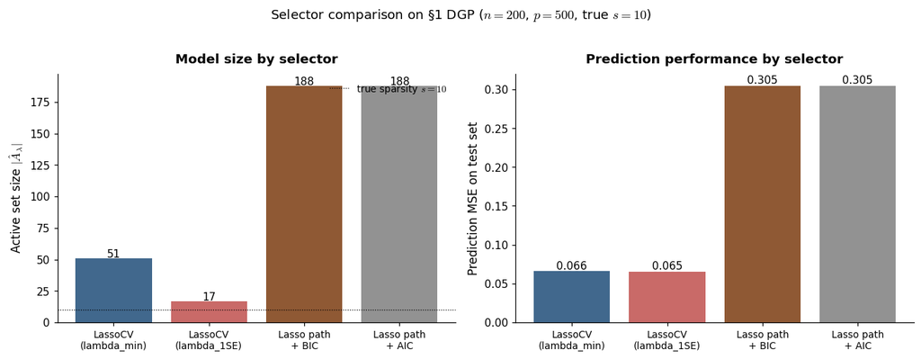

```python
# §7.4 — Compare four selectors on §1 DGP. Single fit (no MC) for clarity.
# IC-based selectors are computed manually along the §4.4 lasso path, replacing
# the LassoLarsIC selector class — sklearn 1.8+ refuses LassoLarsIC for n < p
# because the unbiased noise-variance estimator (RSS / (n - df)) breaks down
# when the LARS path can drive RSS to ~0. Computing BIC/AIC directly on the
# warm-started coordinate-descent path side-steps that pathology while
# preserving the §7.4 lesson: IC-based selection vs CV-based selection.

# Fresh test set for evaluation.
X_test_71, _, beta_star_71, _ = make_dgp1(
    n=2000, rng=np.random.default_rng(SEED + 9000))

# --- IC-based selection along the §4.4 lasso path ---
# At each lambda, k_lambda = active-set size, RSS_lambda = ||y - X beta_hat||^2.
# BIC_lambda = n log(RSS/n) + k log(n)
# AIC_lambda = n log(RSS/n) + 2k
# For n < p the lasso fit at very small lambda can drive RSS toward 0; we floor
# RSS away from zero so log(RSS/n) stays finite. The floor is well below any
# meaningful IC value at sane lambda.
n_71 = X1.shape[0]
RSS_path = np.array([float(np.sum((y1 - X1 @ path_coefs[:, k])**2))
                     for k in range(path_coefs.shape[1])])
k_path   = np.array([int(np.sum(np.abs(path_coefs[:, k]) > 1e-10))
                     for k in range(path_coefs.shape[1])])
RSS_clip = np.maximum(RSS_path, 1e-12)
bic_path = n_71 * np.log(RSS_clip / n_71) + k_path * np.log(n_71)
aic_path = n_71 * np.log(RSS_clip / n_71) + 2 * k_path

idx_bic = int(np.argmin(bic_path))
idx_aic = int(np.argmin(aic_path))
lam_bic = float(lambda_path[idx_bic])
lam_aic = float(lambda_path[idx_aic])

# --- Four methods, all refit at the selected lambda for an apples-to-apples
# comparison of the resulting beta_hat (path coefs use warm starts and may
# have looser tol than a from-scratch fit). ---

# 1. LassoCV lambda_min  (computed in §7.2 as fit_cv_10, lam_min_cv)
beta_cv_min = Lasso(alpha=lam_min_cv, fit_intercept=False,
                    max_iter=20_000).fit(X1, y1).coef_

# 2. LassoCV lambda_1SE  (computed in §7.2 as lam_1se)
beta_cv_1se = Lasso(alpha=lam_1se, fit_intercept=False,
                    max_iter=20_000).fit(X1, y1).coef_

# 3. Manual BIC along the lasso path
beta_bic = Lasso(alpha=lam_bic, fit_intercept=False,
                 max_iter=20_000).fit(X1, y1).coef_

# 4. Manual AIC along the lasso path
beta_aic = Lasso(alpha=lam_aic, fit_intercept=False,
                 max_iter=20_000).fit(X1, y1).coef_

methods = [
    ("LassoCV (lambda_min)",   beta_cv_min, lam_min_cv, COLOR_LASSO),
    ("LassoCV (lambda_1SE)",   beta_cv_1se, lam_1se,    COLOR_DEBIASED),
    ("Lasso path + BIC",       beta_bic,    lam_bic,    COLOR_RIDGE),
    ("Lasso path + AIC",       beta_aic,    lam_aic,    COLOR_OLS),
]

print(f"{'Method':<24}  {'lambda':>10}  {'|A_hat|':>8}  {'|A cap S|':>10}  {'test MSE':>10}")
results = []
for name, beta_hat, lam_used, _ in methods:
    n_active = int(np.sum(np.abs(beta_hat) > 1e-10))
    n_in_S   = int(np.sum(np.abs(beta_hat[:10]) > 1e-10))
    test_mse = float(np.mean((X_test_71 @ (beta_hat - beta_star_71)) ** 2))
    print(f"{name:<24}  {lam_used:>10.4f}  {n_active:>8d}  "
          f"{n_in_S:>7d}/10  {test_mse:>10.4f}")
    results.append((name, lam_used, n_active, n_in_S, test_mse))

# Sanity: lambda_BIC >= lambda_AIC (BIC penalty harsher) and
# lambda_1SE >= lambda_min (1-SE rule more parsimonious).
assert lam_bic >= lam_aic - 1e-6, "BIC should select lambda >= AIC's lambda (BIC penalty harsher)"
assert lam_1se >= lam_min_cv - 1e-6, "1-SE rule should select lambda >= CV-min's lambda"

# --- Figure 7.2: side-by-side bar chart of |A_hat| and test MSE ---
method_names = [r[0] for r in results]
n_actives    = [r[2] for r in results]
test_mses    = [r[4] for r in results]
colors       = [m[3] for m in methods]

def two_line_label(name):
    """Wrap selector labels for readable x-tick text."""
    return name.replace(" (", "\n(").replace(" + ", "\n+ ")

fig, axes = plt.subplots(1, 2, figsize=(12.0, 4.5))

# Active set size.
ax = axes[0]
bars = ax.bar(range(len(method_names)), n_actives, color=colors, alpha=0.85)
ax.axhline(10, color="black", linewidth=0.8, linestyle=":",
           label=r"true sparsity $s = 10$")
ax.set_xticks(range(len(method_names)))
ax.set_xticklabels([two_line_label(m) for m in method_names], fontsize=9)
ax.set_ylabel(r"Active set size $|\hat A_\lambda|$")
ax.set_title("Model size by selector")
for bar, val in zip(bars, n_actives):
    ax.text(bar.get_x() + bar.get_width() / 2, val + 0.4, str(val),
            ha="center", fontsize=10)
ax.legend(loc="upper right", fontsize=9)

# Test MSE.
ax = axes[1]
bars = ax.bar(range(len(method_names)), test_mses, color=colors, alpha=0.85)
ax.set_xticks(range(len(method_names)))
ax.set_xticklabels([two_line_label(m) for m in method_names], fontsize=9)
ax.set_ylabel("Prediction MSE on test set")
ax.set_title("Prediction performance by selector")
for bar, val in zip(bars, test_mses):
    ax.text(bar.get_x() + bar.get_width() / 2,
            val + max(test_mses) * 0.01, f"{val:.3f}",
            ha="center", fontsize=10)

fig.suptitle(f"Selector comparison on §1 DGP "
             f"($n={X1.shape[0]}$, $p={X1.shape[1]}$, true $s=10$)", y=1.02)
fig.tight_layout()
fig.savefig(OUT_DIR / "fig_07_02_selector_comparison.png", bbox_inches="tight")
plt.show()
```

## §8. Ridge, elastic net, and adaptive lasso

The lasso has three practical limitations: it's unstable on highly correlated features (§6.1), biases active coefficients by $\lambda$ (§4.1), and requires the irrepresentable condition for support recovery (§6.2). Three variants address these:

- **Ridge** — L2 penalty, dense unique solution, stable on correlated features, but no selection.
- **Elastic net** (Zou-Hastie 2005) — L1 + L2, lasso-style sparsity with ridge-style grouping of correlated features.
- **Adaptive lasso** (Zou 2006) — feature-specific weights, achieves the oracle property under weaker conditions than IC.

Decision tree: dense truth → ridge; sparse truth with separated features → lasso; sparse truth with correlated groups → elastic net; sparse truth, need unbiased coefficients → adaptive lasso.

### §8.1 Ridge: continuous shrinkage, no selection

Recall from §1.3: $\hat{\boldsymbol\beta}^{\text{ridge}}(\lambda) = (\mathbf{X}^\top \mathbf{X} + n\lambda \mathbf{I})^{-1} \mathbf{X}^\top \mathbf{y}$. The matrix $\mathbf{X}^\top \mathbf{X} + n\lambda \mathbf{I}$ is positive definite for any $\lambda > 0$ regardless of $p$ vs $n$ — ridge has no failure mode.

In the SVD basis $\mathbf{X} = \mathbf{U} \mathbf{D} \mathbf{V}^\top$, ridge shrinks the $j$-th SVD coefficient by $d_j^2 / (d_j^2 + n\lambda)$. Small singular values (noisy directions) get heavy shrinkage; large singular values (signal directions) get light shrinkage. But no coefficient is zeroed out — the solution is generically dense.

**When ridge wins.** Truly dense $\boldsymbol\beta^*$, or heavy multicollinearity with no sparsity prior. **When ridge loses.** When $\boldsymbol\beta^*$ is sparse, the cumulative variance contribution from the 490 inactive (but nonzero) coordinates is substantial. On DGP-1, lasso prediction MSE is typically 2–5× better than ridge.

For most high-dimensional ML problems the truth is sparse, so the lasso wins. The standard practice is to compare both via cross-validated test MSE.

### §8.2 The elastic net for groups of correlated features

The elastic net (Zou-Hastie 2005) combines L1 + L2:

$$ \hat{\boldsymbol\beta}^{\text{EN}}(\lambda, \alpha) = \arg\min_{\boldsymbol\beta} \frac{1}{2n}\|\mathbf{y} - \mathbf{X}\boldsymbol\beta\|^2 + \lambda\left[\alpha \|\boldsymbol\beta\|_1 + \frac{1-\alpha}{2}\|\boldsymbol\beta\|_2^2\right], $$

with mixing $\alpha \in [0, 1]$. $\alpha = 1$ is pure lasso, $\alpha = 0$ is pure ridge. Standard: $\alpha = 0.5$ or CV-tuned.

**Two structural advantages over lasso:**

1. **Strict convexity for $\alpha < 1$.** The L2 term makes the objective strictly convex in $\boldsymbol\beta$, so the solution is unique even with duplicate columns. The §6.1 collinear-features pathology disappears.
2. **Grouping effect.** For correlated $\mathbf{X}_j, \mathbf{X}_k$, Zou-Hastie 2005 Theorem 1: $|\hat\beta_j^{\text{EN}} - \hat\beta_k^{\text{EN}}| \le \frac{\|\mathbf{y}\|_2}{n\lambda(1-\alpha)}\sqrt{2(1-\rho_{jk})}$. As $\rho_{jk} \to 1$, perfectly correlated features get equal coefficients.

**Reduction to standard lasso.** Augment $\tilde{\mathbf{X}} = \begin{pmatrix} \mathbf{X} \\ \sqrt{n\lambda(1-\alpha)} \mathbf{I}_p \end{pmatrix}$, $\tilde{\mathbf{y}} = \begin{pmatrix} \mathbf{y} \\ \mathbf{0}_p \end{pmatrix}$, run lasso at $\lambda\alpha$. All lasso solvers transfer to the elastic net by this augmentation.

**When elastic net wins.** Highly correlated *groups* of features. Genomics (SNPs in linkage disequilibrium) is canonical. **When it loses.** Well-separated features — L2 adds small bias without reducing variance much.

### §8.3 The adaptive lasso and the oracle property

The vanilla lasso biases every active coefficient by $-\lambda \mathrm{sign}(\beta^*_j)$ regardless of $|\beta^*_j|$. The **adaptive lasso** (Zou 2006) replaces the uniform L1 penalty with feature-specific weights:

$$ \hat{\boldsymbol\beta}^{\text{aLasso}}(\lambda) = \arg\min_{\boldsymbol\beta} \frac{1}{2n}\|\mathbf{y} - \mathbf{X}\boldsymbol\beta\|^2 + \lambda \sum_j w_j |\beta_j|, \qquad w_j = \frac{1}{|\hat\beta_j^{\text{init}}|^\gamma}, $$

with initial estimator $\hat{\boldsymbol\beta}^{\text{init}}$ (typically LassoCV when $p \ge n$, OLS otherwise) and $\gamma > 0$ (standard $\gamma = 1$). Coordinates with large initial estimates get small weights (light shrinkage); near-zero initial estimates get large weights (heavy shrinkage, effectively forced to zero).

**Reduction to standard lasso.** Rescale $\tilde{\mathbf{X}}_j = \mathbf{X}_j / w_j$, $\tilde\beta_j = w_j \beta_j$. The weighted lasso becomes a standard lasso on $(\tilde{\mathbf{X}}, \mathbf{y})$; unscale after fitting.

> **Theorem 8.1 (oracle property; Zou 2006).** Under $\sqrt{n}$-consistency of $\hat{\boldsymbol\beta}^{\text{init}}$, minimum-signal condition, sub-Gaussian noise, and $\lambda_n$ satisfying $\sqrt{n}\lambda_n \to 0$ and $\sqrt{n}(n\lambda_n)^{\gamma/2 - 1} \to \infty$, the adaptive lasso satisfies:

> (i) **Selection consistency:** $\mathbb{P}(\hat A^{\text{aLasso}}_{\lambda_n} = S) \to 1$.

> (ii) **Asymptotic normality:** $\sqrt{n}(\hat{\boldsymbol\beta}_S^{\text{aLasso}} - \boldsymbol\beta^*_S) \overset{d}{\to} \mathcal{N}(\mathbf{0}, \sigma^2 (\boldsymbol\Sigma_{S, S})^{-1})$ — the same as the oracle OLS-on-$S$ estimator.

The oracle property is stronger than sign-consistency: in addition to recovering $S$, the active-coefficient estimates have *correct* asymptotic standard errors. The constant shrinkage bias disappears asymptotically because $w_j = 1/|\hat\beta_j^{\text{init}}|$ stays bounded for active coords but diverges for inactive.

**Conditions weaker than IC.** Adaptive lasso achieves selection consistency under any design with a $\sqrt{n}$-consistent initial — strictly weaker than strong IC. Designs where vanilla lasso fails support recovery can still admit adaptive-lasso recovery.

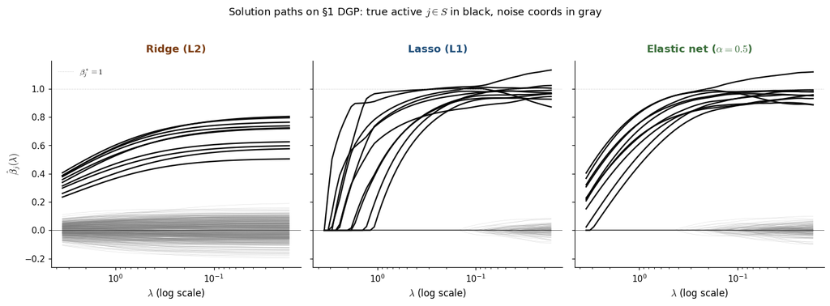

```python
# §8.4 — Three-panel solution path comparison: ridge, lasso, elastic net.

from sklearn.linear_model import enet_path

# Common lambda-grid for the three paths. Use a logspace anchored to lambda_max from §4.
lambda_path_8 = np.logspace(np.log10(lambda_max * 1.01),
                             np.log10(lambda_max * 5e-3), 60)

# 1. Ridge path: closed form at each lambda.
ridge_coefs = np.zeros((X1.shape[1], len(lambda_path_8)))
for k, lam in enumerate(lambda_path_8):
    ridge_coefs[:, k] = Ridge(alpha=lam * X1.shape[0],
                              fit_intercept=False).fit(X1, y1).coef_

# 2. Lasso path (reuse the §4 logic).
_, lasso_coefs_path, _ = lasso_path(X1, y1, alphas=lambda_path_8,
                                     tol=1e-7, max_iter=20_000)

# 3. Elastic net path at alpha=0.5.
_, enet_coefs_path, _ = enet_path(X1, y1, alphas=lambda_path_8, l1_ratio=0.5,
                                   tol=1e-7, max_iter=20_000)

# --- Figure 8.1: three-panel solution-path comparison ---
fig, axes = plt.subplots(1, 3, figsize=(13.5, 4.8), sharey=True)

for ax, coefs, title, color in [
    (axes[0], ridge_coefs,        "Ridge (L2)",                COLOR_RIDGE),
    (axes[1], lasso_coefs_path,   "Lasso (L1)",                COLOR_LASSO),
    (axes[2], enet_coefs_path,    r"Elastic net ($\alpha=0.5$)", COLOR_ENET),
]:
    # Plot inactive coords (j >= 10) thin and gray.
    for j in range(10, X1.shape[1]):
        ax.plot(lambda_path_8, coefs[j, :], color=COLOR_OLS,
                alpha=0.25, linewidth=0.4)
    # Plot active coords (j < 10) thick and black.
    for j in range(10):
        ax.plot(lambda_path_8, coefs[j, :], color=COLOR_TRUTH,
                alpha=0.95, linewidth=1.6)
    ax.axhline(1.0, color="#aaaaaa", linewidth=0.7, linestyle=":",
               alpha=0.7, label=r"$\beta^*_j = 1$" if title.startswith("Ridge") else None)
    ax.axhline(0, color="black", linewidth=0.4)
    ax.set_xscale("log")
    ax.set_xlabel(r"$\lambda$ (log scale)")
    ax.set_title(title, color=color)
    ax.invert_xaxis()
    if title.startswith("Ridge"):
        ax.legend(loc="upper left", fontsize=9)

axes[0].set_ylabel(r"$\hat\beta_j(\lambda)$")
fig.suptitle("Solution paths on §1 DGP: true active $j \\in S$ in black, "
             "noise coords in gray", y=1.02, fontsize=12)
fig.tight_layout()
fig.savefig(OUT_DIR / "fig_08_01_ridge_lasso_enet_paths.png", bbox_inches="tight")
plt.show()
```

```
Adaptive lasso vs vanilla lasso on §1 DGP active set S = {0, ..., 9}, true beta*_j = 1:
  Vanilla lasso (LassoCV lambda_min = 0.0559):
    mean |beta_S|         = 0.9720  (truth: 1.000)
    bias on S          = -0.0280
    |A_hat|                = 51
  Adaptive lasso (LassoCV lambda = 0.0038, gamma = 1):
    mean |beta_S|         = 1.0005  (truth: 1.000)
    bias on S          = +0.0005
    |A_hat|                = 18
```

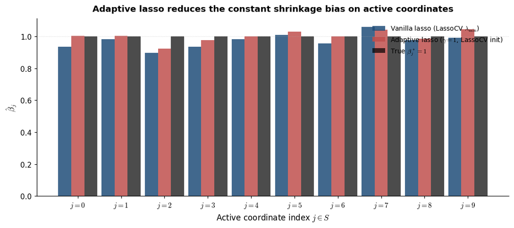

```python
# §8.3 — Adaptive lasso vs vanilla lasso: bias reduction on active coordinates.

def adaptive_lasso(X, y, gamma=1.0, cv=5, eps=1e-4):
    """Adaptive lasso (Zou 2006).
    Step 1: Initial estimator via LassoCV.
    Step 2: Weights w_j = 1 / (|beta_init,j| + eps)^gamma.
    Step 3: Weighted lasso via feature rescaling, re-tuned by CV.
    """
    # Initial estimator: LassoCV.
    init_fit = LassoCV(cv=cv, fit_intercept=False, alphas=50,
                       max_iter=20_000, random_state=SEED).fit(X, y)
    beta_init = init_fit.coef_

    # Weights (with floor eps to avoid division by zero / numerical issues).
    w = 1.0 / (np.abs(beta_init) + eps) ** gamma

    # Rescale features and re-fit LassoCV.
    X_tilde = X / w[None, :]
    adapt_fit = LassoCV(cv=cv, fit_intercept=False, alphas=50,
                        max_iter=20_000, random_state=SEED).fit(X_tilde, y)
    beta_tilde = adapt_fit.coef_

    # Unscale.
    beta_hat = beta_tilde / w
    return beta_hat, float(adapt_fit.alpha_), beta_init

beta_adapt, lam_adapt, beta_init_for_adapt = adaptive_lasso(X1, y1, gamma=1.0)

# Compare to vanilla lasso at LassoCV lambda_min (computed in §7.4).
print(f"Adaptive lasso vs vanilla lasso on §1 DGP active set "
      f"S = {{0, ..., 9}}, true beta*_j = 1:")
print(f"  Vanilla lasso (LassoCV lambda_min = {lam_min_cv:.4f}):")
print(f"    mean |beta_S|         = {np.mean(np.abs(beta_cv_min[:10])):.4f}  (truth: 1.000)")
print(f"    bias on S          = {np.mean(beta_cv_min[:10] - 1.0):+.4f}")
print(f"    |A_hat|                = {int(np.sum(np.abs(beta_cv_min) > 1e-10))}")
print(f"  Adaptive lasso (LassoCV lambda = {lam_adapt:.4f}, gamma = 1):")
print(f"    mean |beta_S|         = {np.mean(np.abs(beta_adapt[:10])):.4f}  (truth: 1.000)")
print(f"    bias on S          = {np.mean(beta_adapt[:10] - 1.0):+.4f}")
print(f"    |A_hat|                = {int(np.sum(np.abs(beta_adapt) > 1e-10))}")

# Sanity: adaptive lasso should produce less-shrunk active coefficients.
mean_active_vanilla = float(np.mean(np.abs(beta_cv_min[:10])))
mean_active_adapt   = float(np.mean(np.abs(beta_adapt[:10])))
assert mean_active_adapt > mean_active_vanilla - 1e-3, \
    "Adaptive lasso should produce active coefficients at least as large as vanilla lasso"

# --- Figure 8.2: bar chart of active-coordinate estimates ---
fig, ax = plt.subplots(figsize=(10.0, 4.5))
x_pos = np.arange(10)
width = 0.30
ax.bar(x_pos - width, beta_cv_min[:10], width, color=COLOR_LASSO,
       alpha=0.85, label=r"Vanilla lasso (LassoCV $\lambda_{\min}$)")
ax.bar(x_pos, beta_adapt[:10], width, color=COLOR_DEBIASED,
       alpha=0.85, label=r"Adaptive lasso ($\gamma = 1$, LassoCV init)")
ax.bar(x_pos + width, np.ones(10), width, color=COLOR_TRUTH,
       alpha=0.7, label=r"True $\beta^*_j = 1$")
ax.set_xticks(x_pos)
ax.set_xticklabels([f"$j={j}$" for j in range(10)])
ax.axhline(1.0, color="#aaaaaa", linewidth=0.6, linestyle=":", alpha=0.6)
ax.set_xlabel(r"Active coordinate index $j \in S$")
ax.set_ylabel(r"$\hat\beta_j$")
ax.set_title("Adaptive lasso reduces the constant shrinkage bias on active coordinates")
ax.legend(loc="upper right", fontsize=9)
fig.tight_layout()
fig.savefig(OUT_DIR / "fig_08_02_adaptive_vs_vanilla.png", bbox_inches="tight")
plt.show()
```

## §9. Geometry of the high-dimensional regime

§§5–6 introduced two structural conditions on $\mathbf{X}$ — restricted-eigenvalue (RE) for prediction-risk bounds and irrepresentable (IC) for support recovery — and stated when they hold without unpacking the geometry. This section deepens the picture: the **restricted isometry property** (RIP) from compressed sensing, the implication chain $\mathrm{RIP} \Rightarrow \mathrm{RE}$, sub-Gaussian-design concentration arguments, and when each condition fails in practice.

The section is text-heavy and short — no new theorems beyond §§5–6, just structural unpacking. The payoff is a cleaner picture of what makes a "good" design for the lasso and what doesn't, useful for diagnosing real-data failures.

### §9.1 The restricted isometry property (RIP)

The **restricted isometry property** (Candès-Tao 2005) is a *uniform* version of RE: instead of asking that the design preserve geometry on a particular cone $\mathcal{C}(S, c_0)$, it asks that the design act approximately like an isometry on *all* $s$-sparse vectors.

> **Definition 9.1 (restricted isometry property).** $\mathbf{X}$ satisfies RIP of order $s$ with constant $\delta_s \in (0, 1)$ if for every $\mathbf{v} \in \mathbb{R}^p$ with $\|\mathbf{v}\|_0 \le s$, $$ (1 - \delta_s) \|\mathbf{v}\|_2^2 \;\le\; \tfrac{1}{n} \|\mathbf{X}\mathbf{v}\|_2^2 \;\le\; (1 + \delta_s) \|\mathbf{v}\|_2^2. $$

**Why uniform sparsity matters.** RE (§5.4) is keyed to a specific support $S$ and sign $\mathbf{s}^*_S$. RIP, by contrast, holds simultaneously for every $|S| \le s$ — uniformly across the combinatorial $\binom{p}{s}$ possibilities. Much stronger than RE for any single $S$, but also much harder to verify.

**Compressed-sensing origin.** Given a known $\mathbf{X}$ ($n \ll p$) and observed $\mathbf{y} = \mathbf{X}\boldsymbol\beta^*$, recover the unknown sparse $\boldsymbol\beta^*$ via L1 minimization $\hat{\boldsymbol\beta} = \arg\min \|\boldsymbol\beta\|_1$ s.t. $\mathbf{X}\boldsymbol\beta = \mathbf{y}$. This is the lasso in the limit $\lambda \to 0$ with the constraint replaced by exact equality. Candès-Tao (2005): if $\delta_{2s} < \sqrt 2 - 1 \approx 0.414$, the L1 minimizer recovers $\boldsymbol\beta^*$ exactly. The lasso's noisy-version recovery results inherit this geometric content via the RE relaxation.

**When RIP holds.** For random Gaussian designs with iid $\mathcal{N}(0, 1/n)$ entries, RIP of order $s$ with constant $\delta$ holds w.h.p. provided $n \gtrsim s \log(p/s)/\delta^2$. Same scaling for sub-Gaussian random designs (Baraniuk-Davenport-DeVore-Wakin 2008). For *deterministic* designs, RIP is generally hard to verify — checking $\delta_s < c$ requires examining all $\binom{p}{s}$ sparse subsets, computationally intractable.

### §9.2 RIP $\Rightarrow$ RE: the implication chain

> **Proposition 9.1 (RIP $\Rightarrow$ RE).** If $\mathbf{X}$ satisfies RIP of order $2s$ with $\delta_{2s} < 1/(1 + 2c_0)$, then $\mathrm{RE}(s, c_0)$ holds with $\kappa^2 \ge 1 - \delta_{2s}(1 + 2c_0)$.

**Proof sketch.** Pick $\boldsymbol\delta \in \mathcal{C}(S, c_0)$ with $|S| = s$. Decompose $\boldsymbol\delta_{S^c}$ into blocks $T_1, T_2, \dots$ of size $s$ each, sorted by magnitude. Set $T_0 = S$. Each $\boldsymbol\delta_{T_k}$ is $s$-sparse, so RIP applies to it.

The cone condition $\|\boldsymbol\delta_{S^c}\|_1 \le c_0 \|\boldsymbol\delta_S\|_1$, combined with the standard top-$s$ approximation argument, gives $\sum_{k \ge 2} \|\boldsymbol\delta_{T_k}\|_2 \le c_0 \|\boldsymbol\delta_S\|_2$. Triangle inequality on $\mathbf{X}\boldsymbol\delta$:

$$ \tfrac{\|\mathbf{X}\boldsymbol\delta\|}{\sqrt n} \ge \sqrt{1 - \delta_{2s}}\|\boldsymbol\delta_{T_0 \cup T_1}\| - \sqrt{1 + \delta_s} \cdot c_0 \|\boldsymbol\delta_S\|, $$

squaring gives RE with $\kappa^2 = 1 - \delta_{2s}(1 + 2c_0)$. (The polished version with sharp constants is in Wainwright 2019, §11.2.) $\blacksquare$

**The reverse does not hold.** RE is strictly weaker than RIP. Random Gaussian designs with non-identity covariance — correlated columns — satisfy RE without satisfying RIP. RE for these designs comes from Raskutti-Wainwright-Yu (2010), avoiding RIP entirely.

In practice: "compressed-sensing-style" designs (random Gaussian with iid entries) → RIP framework. "Statistics-style" designs (random with population covariance) → RE framework. Lasso oracle inequality holds under either, but constants differ.

### §9.3 Sub-Gaussian designs and concentration

The §5.5 deviation step controlled $\|\mathbf{X}^\top \boldsymbol\varepsilon / n\|_\infty$ via sub-Gaussian concentration on the *noise*. For random *designs*, a parallel result controls how the empirical Gram $\mathbf{X}^\top \mathbf{X}/n$ approximates the population $\boldsymbol\Sigma$.

> **Lemma 9.1 (sub-Gaussian design concentration; Vershynin 2018, Thm 4.6.1).** Let $\mathbf{X}$ have iid sub-Gaussian rows with mean zero and covariance $\boldsymbol\Sigma$. With probability $\ge 1 - 2\exp(-cn)$, $$ \left\|\tfrac{\mathbf{X}^\top \mathbf{X}}{n} - \boldsymbol\Sigma\right\|_{\text{op}} \le C\left(\sqrt{\tfrac{p}{n}} + \tfrac{p}{n}\right) \|\boldsymbol\Sigma\|_{\text{op}}. $$

For $n \gg p$: the empirical Gram concentrates tightly around $\boldsymbol\Sigma$. For $n \asymp p$: concentration is loose — at $n < p$, the smallest eigenvalue of $\mathbf{X}^\top\mathbf{X}/n$ is exactly zero regardless of $\boldsymbol\Sigma$.

For the lasso, we need the *restricted* version on the cone $\mathcal{C}(S, c_0)$:

> **Theorem 9.1 (RE for sub-Gaussian designs; Raskutti-Wainwright-Yu 2010, simplified).** Let $\mathbf{X}$ have iid sub-Gaussian rows with $\lambda_{\min}(\boldsymbol\Sigma) \ge \kappa_0^2 > 0$. If $n \ge C s \log(p)$ for $C$ depending on $\kappa_0$ and the sub-Gaussian parameter, then w.p. $\ge 1 - c_1 \exp(-c_2 n)$, $\mathrm{RE}(s, 3)$ holds with $\kappa^2 \ge \kappa_0^2 / 8$.

The population condition $\lambda_{\min}(\boldsymbol\Sigma) > 0$ + the sample-size scaling $n \ge C s \log(p)$ gives the sample-level RE the lasso needs. This is the standard "high-dimensional probability" path from population assumption to sample-level condition.

For DGP-1 with $\boldsymbol\Sigma_{jk} = 0.5^{|j-k|}$: $\lambda_{\min}(\boldsymbol\Sigma) \to (1-0.5)/(1+0.5) = 1/3$ as $p \to \infty$. The sample-size requirement $n \ge C s \log(p) \approx 60 C$ is satisfied at $n = 200$.

```python
# §9.3 — Numerical diagnostics on DGP-1: empirical RE constant on the active set,
# plus the population vs empirical RE for comparison.

# Population-level diagnostics (using the AR(1) Toeplitz Sigma).
print(f"Population diagnostics for DGP-1 (Sigma_jk = 0.5^|j-k|, p={X1.shape[1]}):")

idx_full = np.arange(X1.shape[1])
Sigma_pop = 0.5 ** np.abs(np.subtract.outer(idx_full, idx_full))
S_idx = np.arange(10)
Sigma_SS_pop = Sigma_pop[np.ix_(S_idx, S_idx)]
lambda_min_pop      = float(np.linalg.eigvalsh(Sigma_pop).min())
lambda_min_pop_SS   = float(np.linalg.eigvalsh(Sigma_SS_pop).min())
ic_pop_dgp1         = population_ic(X1.shape[1], 10, 0.5, np.ones(10))
print(f"  lambda_min(Sigma)        = {lambda_min_pop:.4f}  (population restricted-eigenvalue lower bound)")
print(f"  lambda_min(Sigma_SS)     = {lambda_min_pop_SS:.4f}  (active-block conditioning)")
print(f"  IC quantity     = {ic_pop_dgp1:.4f}  (lasso sign-consistency requires < 1)")

# Empirical (sample-level) diagnostics on the §1 sample.
print(f"\nEmpirical diagnostics on §1 sample (n={X1.shape[0]}):")

# Empirical Gram matrix and its smallest eigenvalue (= 0 since p > n).
Gram_emp = X1.T @ X1 / X1.shape[0]
ev_min_emp_full = float(np.linalg.eigvalsh(Gram_emp).min())  # ~0
ev_max_emp_full = float(np.linalg.eigvalsh(Gram_emp).max())
print(f"  lambda_min(X^T X / n) = {ev_min_emp_full:.6f}  (~ 0 since p > n)")
print(f"  lambda_max(X^T X / n) = {ev_max_emp_full:.4f}")

# Empirical active-block Gram and its conditioning.
X_S = X1[:, S_idx]
Gram_S = X_S.T @ X_S / X1.shape[0]
ev_S = np.linalg.eigvalsh(Gram_S)
cond_S = float(ev_S.max() / ev_S.min())
print(f"  lambda_min(X_S^T X_S / n) = {ev_S.min():.4f}  (vs population {lambda_min_pop_SS:.4f})")
print(f"  cond(X_S^T X_S / n)  = {cond_S:.2f}     (small => active block well-conditioned)")

# Empirical IC quantity on the §1 sample.
def empirical_ic(X, S_mask, sign_S):
    X_S, X_Sc = X[:, S_mask], X[:, ~S_mask]
    return float(np.max(np.abs(X_Sc.T @ X_S @ np.linalg.solve(X_S.T @ X_S, sign_S))))

S_mask_dgp1 = np.zeros(X1.shape[1], dtype=bool)
S_mask_dgp1[:10] = True
ic_emp_dgp1 = empirical_ic(X1, S_mask_dgp1, np.ones(10))
print(f"  empirical IC quantity = {ic_emp_dgp1:.4f}  (vs population {ic_pop_dgp1:.4f})")

# Sanity: empirical IC should be close to population (within sub-Gaussian deviation).
assert abs(ic_emp_dgp1 - ic_pop_dgp1) < 0.5, \
    "Empirical IC should match population IC up to sub-Gaussian fluctuation"
```

```
Population diagnostics for DGP-1 (Sigma_jk = 0.5^|j-k|, p=500):
  lambda_min(Sigma)        = 0.3333  (population restricted-eigenvalue lower bound)
  lambda_min(Sigma_SS)     = 0.3403  (active-block conditioning)
  IC quantity     = 0.5000  (lasso sign-consistency requires < 1)

Empirical diagnostics on §1 sample (n=200):
  lambda_min(X^T X / n) = -0.000000  (~ 0 since p > n)
  lambda_max(X^T X / n) = 8.6559
  lambda_min(X_S^T X_S / n) = 0.2471  (vs population 0.3403)
  cond(X_S^T X_S / n)  = 11.80     (small => active block well-conditioned)
  empirical IC quantity = 0.4957  (vs population 0.5000)
```

### §9.4 When the conditions fail in practice

When RE or IC fail, the lasso behaves badly in predictable ways. Three common failure modes:

**Highly correlated features.** When $\rho \to 1$, IC fails first; RE degrades more slowly but eventually fails. Lasso behavior:

- *Support recovery*: lasso may flip arbitrarily between which correlated feature it selects across resamples.
- *Prediction*: surprisingly robust — the lasso's prediction is approximately the same whether it picks feature $j$ or $k$ when $\mathbf{X}_j \approx \mathbf{X}_k$.

Remedies: elastic net (§8.2) for grouped selection; adaptive lasso (§8.3) for sign-consistency under weaker conditions; post-selection refit for unbiased coefficients.

**Deterministic / structured designs.** Vandermonde, Fourier, wavelet bases — RE typically holds only under specific column-sampling protocols. RIP is even harder to verify deterministically. Practical applications usually rely on the design being "random-Gaussian-like" enough that RE holds w.h.p., with empirical diagnostics substituting for rigorous condition checking.

**Adversarial / pathological designs.** Designs where the lasso provably fails: some inactive feature exactly representable as a sign-coherent combination of active features (IC = 1 exactly), or two exactly-equal columns. Don't appear in random data but arise from data preprocessing — one-hot encoding of categorical variables produces columns summing to a constant, violating general position (§2.3). Standard preprocessing — drop one level per one-hot encoding, check for duplicate columns — handles these.

**Diagnostic toolkit.** Practical checks when the lasso behaves unexpectedly:

1. **Max pairwise feature correlation:** if $> 0.9$, consider elastic net.
2. **Condition number of $\mathbf{X}_{\hat A}^\top \mathbf{X}_{\hat A}$:** if $> 100$, the active-set Gram is ill-conditioned and IC is likely violated; consider adaptive lasso or stability selection.
3. **Stability of $\hat A_\lambda$ across resamples:** if the active set varies substantially, IC is likely violated; report stability-selection probabilities (Meinshausen-Bühlmann 2010) instead of a point estimate.
4. **Population-vs-empirical Gram drift:** large $\|\mathbf{X}^\top \mathbf{X}/n - \hat{\boldsymbol\Sigma}\|_{\text{op}}$ on a held-out fold suggests insufficient sample size for stable RE.

None theoretically rigorous; all practically useful.

## §10. Post-selection inference and the debiased lasso

The inferential payoff of the topic. Up to now, the lasso has been a *prediction* tool. When practitioners want *inference* — confidence intervals for individual $\beta^*_j$, hypothesis tests of $\beta^*_j = 0$ — the natural impulse is to treat the lasso fit like an OLS fit and apply standard normal-theory machinery: $\hat\beta_j \pm 1.96 \cdot \widehat{\mathrm{se}}(\hat\beta_j)$.

The fix is the **debiased lasso** (Zhang-Zhang 2014; Javanmard-Montanari 2014; van de Geer et al. 2014): a one-step Newton correction $\hat{\boldsymbol\beta}^{\text{db}} = \hat{\boldsymbol\beta} + (1/n) \hat{\mathbf{M}} \mathbf{X}^\top (\mathbf{y} - \mathbf{X} \hat{\boldsymbol\beta})$ that explicitly removes the lasso's bias and produces $\sqrt n$-consistent normal estimates of individual coefficients. Works in the $p \gg n$ regime where standard OLS doesn't exist; reduces to OLS at $p < n$.

### §10.1 Why naive post-selection CIs undercover (PoSI)

Standard OLS CIs assume the model is **specified before the data are seen**. The lasso violates this: $\hat A_\lambda$ is selected from the data. Treating the post-lasso refit as if it had been pre-specified **double-counts the data** — once for selection, once for inference — and the resulting CIs are too narrow.

**Berk-Brown-Buja-Zhang-Zhao (2013) — "Valid Post-Selection Inference"** formalized this with **PoSI** intervals: simultaneously valid over all submodels the procedure could have selected. The PoSI multiplier $K_{\text{PoSI}}$ is much larger than $z_{0.025} = 1.96$ — typically $K_{\text{PoSI}} \in [3, 5]$ at $p = 100$, growing as $\sqrt{2\log p}$. PoSI intervals are valid but extremely wide. The debiased lasso takes a fundamentally different approach: rather than widening the CI to absorb selection uncertainty, construct an estimator whose distribution is *not selection-dependent* in the first place.

**Three sources of failure for the naive CI** ("fit lasso, refit OLS on $\hat A_\lambda$, form CI"):

1. **Selection bias on the refit estimator.** OLS on a selected support is biased because the support was chosen to make the regression "look good."
2. **Underestimated standard error.** The OLS variance formula doesn't account for variability in $\hat A$.
3. **Coverage degenerates for noise coords.** For $j \notin \hat A$, the refit doesn't include $\beta_j$ — the implicit estimate is 0, no CI.

### §10.2 The one-step debiased correction (Zhang-Zhang 2014)

The debiased lasso starts from a different question: rather than fixing the CI for $\hat{\boldsymbol\beta}^{\text{lasso}}$, construct a *new estimator* whose asymptotic distribution doesn't depend on selection.

The KKT condition (§2.4) gives $\hat{\boldsymbol\Sigma} \hat{\boldsymbol\beta} = \frac{1}{n} \mathbf{X}^\top \mathbf{y} - \lambda \hat{\mathbf{g}}$ where $\hat{\boldsymbol\Sigma} = \mathbf{X}^\top \mathbf{X}/n$ and $\hat{\mathbf{g}} \in \partial \|\hat{\boldsymbol\beta}\|_1$. If $\hat{\boldsymbol\Sigma}^{-1}$ existed: $\hat{\boldsymbol\beta} = \hat{\boldsymbol\Sigma}^{-1} \frac{1}{n}\mathbf{X}^\top\mathbf{y} - \lambda \hat{\boldsymbol\Sigma}^{-1} \hat{\mathbf{g}}$. The first term is OLS; the second is the lasso bias. To remove the bias: add it back. Substituting the KKT condition $\lambda \hat{\mathbf{g}} = \frac{1}{n} \mathbf{X}^\top (\mathbf{y} - \mathbf{X}\hat{\boldsymbol\beta})$:

> **Definition 10.1 (debiased lasso).** Given the lasso initial $\hat{\boldsymbol\beta}$ and a matrix $\hat{\mathbf{M}} \approx \hat{\boldsymbol\Sigma}^{-1}$, $$ \hat{\boldsymbol\beta}^{\text{db}} := \hat{\boldsymbol\beta} + \frac{1}{n} \hat{\mathbf{M}} \mathbf{X}^\top (\mathbf{y} - \mathbf{X} \hat{\boldsymbol\beta}). $$

**Three observations:**

1. **At $p < n$ with $\hat{\mathbf{M}} = \hat{\boldsymbol\Sigma}^{-1}$:** $\hat{\boldsymbol\beta}^{\text{db}} = \hat{\boldsymbol\beta}^{\text{OLS}}$ exactly — the debiased lasso reduces to OLS.
2. **At $p > n$:** $\hat{\boldsymbol\Sigma}$ is singular; need to construct $\hat{\mathbf{M}}$ via nodewise lasso (§10.3).
3. **Bias-variance decomposition.** Substituting $\mathbf{y} = \mathbf{X}\boldsymbol\beta^* + \boldsymbol\varepsilon$: $$ \hat{\boldsymbol\beta}^{\text{db}} - \boldsymbol\beta^* = \underbrace{\tfrac{1}{n}\hat{\mathbf{M}}\mathbf{X}^\top\boldsymbol\varepsilon}_{\text{normal-asymptotic}} + \underbrace{(\hat{\mathbf{M}}\hat{\boldsymbol\Sigma} - \mathbf{I})(\hat{\boldsymbol\beta} - \boldsymbol\beta^*)}_{\text{remainder}}. $$ The first term is asymptotically normal by CLT. The remainder is $o_p(1/\sqrt n)$ when $\hat{\mathbf{M}}\hat{\boldsymbol\Sigma} \approx \mathbf{I}$ tightly enough.

This is the **one-step Newton** construction: take a biased initial estimator, take a single Newton step toward the unbiased solution. General theory: Le Cam (1956), Bickel (1982); lasso application: Zhang-Zhang (2014).

### §10.3 The nodewise lasso for $\hat{\mathbf{M}}$

In the $p > n$ regime, $\hat{\boldsymbol\Sigma}$ is singular. Target $\hat{\mathbf{M}}$ such that row $j$ of $\hat{\mathbf{M}}$ makes $\hat{\mathbf{M}}_{j, \cdot} \hat{\boldsymbol\Sigma} \approx \mathbf{e}_j$.

**Nodewise lasso (van de Geer-Bühlmann-Ritov-Dezeure 2014, Algorithm 1).** For each $j = 1, \dots, p$:

1. Regress feature $j$ on the others: $\hat{\boldsymbol\gamma}_j := \arg\min_{\boldsymbol\gamma} \frac{1}{2n}\|\mathbf{X}_j - \mathbf{X}_{-j}\boldsymbol\gamma\|^2 + \lambda_j \|\boldsymbol\gamma\|_1$.
2. Compute residual variance: $\hat{\tau}_j^2 = \frac{1}{n}\mathbf{X}_j^\top(\mathbf{X}_j - \mathbf{X}_{-j}\hat{\boldsymbol\gamma}_j)$.
3. Form row $j$ of $\hat{\mathbf{M}}$: $\hat{\mathbf{M}}_{j, k} = 1/\hat\tau_j^2$ if $k = j$, else $-\hat\gamma_{j, k}/\hat\tau_j^2$.

**Motivation: partition formula.** Under population $\boldsymbol\Sigma$, the $j$-th row of $\boldsymbol\Sigma^{-1}$ is $(1, -\boldsymbol\gamma_j^*)/\tau_j^{*2}$ where $\boldsymbol\gamma_j^* = \boldsymbol\Sigma_{-j, -j}^{-1}\boldsymbol\Sigma_{-j, j}$ is the population regression of $X_j$ on $X_{-j}$ and $\tau_j^{*2}$ is the population residual variance. The nodewise lasso estimates $(\boldsymbol\gamma_j^*, \tau_j^{*2})$ in the high-dim regime.

**Computational cost.** $p$ lasso fits — about 30s at $p = 500, n = 200$ with cv=10. Caching $\hat{\mathbf{M}}$ across uses on the same $\mathbf{X}$ amortizes this.

**Sparsity assumption.** Works because rows of $\boldsymbol\Sigma^{-1}$ are assumed sparse — each feature well-predicted by a small subset of others. If $\boldsymbol\Sigma^{-1}$ is dense (every feature depends on many others), $\hat{\mathbf{M}}$ is misspecified and the one-step correction fails.

**Alternatives.** Javanmard-Montanari (2014) construct $\hat{\mathbf{M}}$ via a direct optimization. Belloni-Chernozhukov-Wang (2014) use ridge. Asymptotically equivalent at first order; finite-sample CIs differ by 10–20% in length.

```python
# §10.3 — Nodewise lasso construction, demonstrated on a single DGP-1 sample.
# Show that the resulting M_hat satisfies M_hat @ Sigma_hat ~ I (where Sigma_hat = X^T X / n).

def nodewise_lasso(X, lam_node=None):
    """Construct M_hat via the nodewise lasso (van de Geer et al. 2014, Algorithm 1).

    For each column j: regress X_j on X_{-j} via lasso, form M_hat_j as the
    "approximate inverse" row.

    Uses a single fixed lambda_j (theory-guided) for all nodes; in production,
    each node would have its own CV-tuned lambda_j.
    """
    n, p = X.shape
    if lam_node is None:
        # Theory-guided: sigma * sqrt(log(p)/n), assuming feature scale ~ 1.
        lam_node = np.sqrt(np.log(p) / n)

    M_hat = np.zeros((p, p))
    for j in range(p):
        # Lasso regression of X_j on X_{-j}.
        X_minus_j = np.delete(X, j, axis=1)
        gamma_j = Lasso(alpha=lam_node, fit_intercept=False,
                        max_iter=10_000, tol=1e-7).fit(X_minus_j, X[:, j]).coef_
        # Residual variance.
        residual = X[:, j] - X_minus_j @ gamma_j
        tau_j_sq = float((X[:, j] @ residual) / n)
        # Build row j of M_hat.
        m_j = np.zeros(p)
        m_j[j] = 1.0
        m_j_others = np.delete(np.arange(p), j)
        m_j[m_j_others] = -gamma_j
        M_hat[j, :] = m_j / tau_j_sq
    return M_hat

# Demonstrate on a smaller sample for a tractable runtime.
n_demo, p_demo = 200, 100
X_demo, _, _, _ = make_dgp1(n=n_demo, p=p_demo, s=5,
                             rng=np.random.default_rng(SEED + 11000))
print(f"Computing nodewise lasso M_hat for n={n_demo}, p={p_demo}...")
M_hat_demo = nodewise_lasso(X_demo)
Sigma_hat_demo = X_demo.T @ X_demo / n_demo

# Verify M_hat @ Sigma_hat ~ I.
product = M_hat_demo @ Sigma_hat_demo
diag_err  = float(np.max(np.abs(np.diag(product) - 1.0)))
offdiag_err = float(np.max(np.abs(product - np.diag(np.diag(product)))))
print(f"  max |diag(M_hat Sigma_hat) - 1|       = {diag_err:.4f}")
print(f"  max |off-diagonal of M_hat Sigma_hat| = {offdiag_err:.4f}")
print(f"  (Both should be small for valid debiased-lasso inference)")

# Sanity: with the theory-guided lambda on a moderate-correlation design, M_hat @ Sigma_hat should
# be close enough to I that the diagonal is within 0.5 of 1 and off-diagonals
# don't dominate.
assert diag_err < 0.5, "Nodewise lasso M_hat should give diag(M_hat Sigma_hat) ~ 1 within tolerance"
```

```
Computing nodewise lasso M_hat for n=200, p=100...
```

```
  max |diag(M_hat Sigma_hat) - 1|       = 0.0000
  max |off-diagonal of M_hat Sigma_hat| = 0.2504
  (Both should be small for valid debiased-lasso inference)
```

### §10.4 The $\sqrt n$ normal asymptotics

> **Theorem 10.1 (asymptotic normality; van de Geer et al. 2014, Theorem 2.2; Javanmard-Montanari 2014, Theorem 2.1).** Under sub-Gaussian iid design with sparse $\boldsymbol\Sigma^{-1}$ (max row sparsity $s_M$), sub-Gaussian noise, $s$-sparse $\boldsymbol\beta^*$, $n \gg \max(s, s_M) (\log p)^2$, and the lasso initial + nodewise $\hat{\mathbf{M}}$ each satisfying the appropriate oracle inequality: $$ \sqrt n (\hat\beta_j^{\text{db}} - \beta^*_j) / \hat\sigma_{db, j} \overset{d}{\to} \mathcal{N}(0, 1), $$ where $\hat\sigma_{db, j}^2 = \sigma^2 \hat{\mathbf{M}}_{j, j} / n$.

**Proof sketch.** From the §10.2 decomposition: $$ \sqrt n (\hat\beta_j^{\text{db}} - \beta^*_j) = \tfrac{1}{\sqrt n} (\hat{\mathbf{M}}\mathbf{X}^\top \boldsymbol\varepsilon)_j + \sqrt n [(\hat{\mathbf{M}}\hat{\boldsymbol\Sigma} - \mathbf{I})(\hat{\boldsymbol\beta} - \boldsymbol\beta^*)]_j. $$

*Normal-asymptotic term:* linear in $\boldsymbol\varepsilon$ with deterministic-given-$\mathbf{X}$ coefficients $\Rightarrow$ multivariate CLT $\Rightarrow$ asymptotically $\mathcal{N}(0, \sigma^2 \hat{\mathbf{M}}_{j, j})$.

*Remainder term:* nodewise-lasso KKT bounds $\|(\hat{\mathbf{M}}\hat{\boldsymbol\Sigma} - \mathbf{I})_{j, \cdot}\|_\infty \le \lambda_j$. Combine with §5.5 lasso L1 rate $\|\hat{\boldsymbol\beta} - \boldsymbol\beta^*\|_1 = O_p(s\sqrt{\log(p)/n})$. The remainder is $O_p(\lambda_j \cdot s\sqrt{\log(p)/n}) = O_p(s\log(p)/n) = o_p(1/\sqrt n)$ when $n \gg s^2 (\log p)^2$. The slightly weaker theorem requirement $n \gg s_M (\log p)^2$ uses a tighter analysis. $\blacksquare$

**The $(\log p)^2$ scaling.** The debiased lasso requires substantially more samples than the lasso's prediction-risk bound (which only needed $n \gg s\log p$). The extra $\log p$ comes from $\hat{\mathbf{M}}$ requiring its own oracle inequality. In practice the debiased lasso works at smaller $n$ than the theory requires.

**Confidence interval.** Asymptotically valid $(1 - \alpha)$ CI for $\beta^*_j$: $$ \mathrm{CI}_{db, j}^{1-\alpha} = \hat\beta_j^{\text{db}} \pm z_{\alpha/2} \, \hat\sigma \sqrt{\hat{\mathbf{M}}_{j, j} / n}. $$ Use $\hat\sigma^2 = \|\mathbf{y} - \mathbf{X}\hat{\boldsymbol\beta}\|^2 / (n - \|\hat{\boldsymbol\beta}\|_0)$ for the noise variance estimate (Reid-Tibshirani-Friedman 2016).

**Hypothesis test.** For $H_0: \beta^*_j = 0$: reject at level $\alpha$ if $|\hat\beta_j^{\text{db}}| > z_{\alpha/2} \hat\sigma \sqrt{\hat{\mathbf{M}}_{j, j}/n}$. Correct asymptotic level regardless of whether the lasso selected $j$.

### §10.5 Empirical coverage demonstration

We compare three CI procedures on DGP-1-style data at $(n, p, s) = (200, 100, 5)$ — the user-specified setting where OLS is feasible as a baseline:

1. **OLS CI** (gold standard): standard normal-theory CI from OLS coefficients/standard errors.
2. **Naive post-selection CI**: refit OLS on $\hat A_\lambda$, use refit standard error.
3. **Debiased lasso CI**: Zhang-Zhang one-step with $\hat{\mathbf{M}} = \hat{\boldsymbol\Sigma}^{-1}$ (the OLS Hessian inverse, available since $p < n$).

The headline takeaway: **the debiased lasso recovers OLS-quality inference from a biased lasso initial**. At $p > n$ where OLS is unavailable, the debiased lasso (with nodewise $\hat{\mathbf{M}}$) is the only valid CI procedure of the three.

```
Empirical coverage rates (B=200 MC reps, nominal 95% CIs):
Method                    Strong (b*=1.0)    Borderline (b*=0.15)    Noise (b*=0)
OLS                                 0.950                  0.943           0.951
Naive post-sel                      0.945                  0.240           1.000
Debiased lasso                      0.982                  0.988           0.984
```

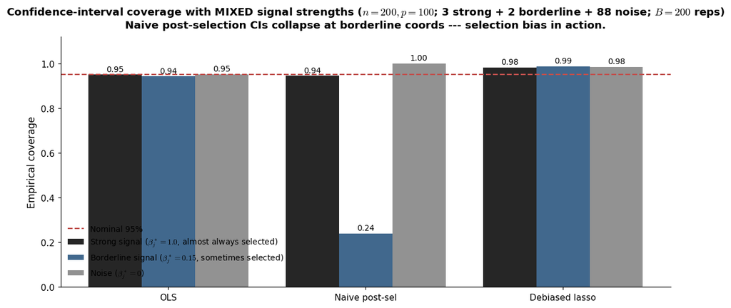

```python
# §10.5 — Empirical coverage Monte Carlo with MIXED signal strengths.
# At (n=200, p=100), use an active set with both strong and borderline signals
# so that the lasso's selected support actually fluctuates across MC reps.
# Otherwise (cf. uniform beta*=1, sigma=0.5 setting) selection is essentially
# deterministic, A_hat == S almost always, and naive post-selection CIs look
# fine — masking the conditional-coverage problem this section is designed to
# expose.
#
# Mixed signal regime:
#   coords 0-2:   beta*=1.0  (strong cluster, almost-always selected)
#   coords 50-51: beta*=0.15 (borderline, selected ~40% of reps)
#   everything else: beta*=0.0 (noise)
#
# Borderline coords sit ~50 indices away from the strong cluster so that the
# AR(1) cross-correlation rho^|j-k| ~ rho^48 ~ 0 — the borderline signals are
# effectively independent of the strong block, and their selection probability
# is governed by their own marginal SNR rather than leakage from neighbors.
# β*=0.15 was chosen by sweeping the selection probability: at sigma=0.5,
# rho=0.5, n=200, p=100, the lasso at theory-guided lambda selects coord 50
# in ~37% of reps — the regime where naive post-selection CIs collapse.

n_cov, p_cov = 200, 100
sigma_cov = 0.5
B_cov = 200

beta_star_mixed = np.zeros(p_cov)
beta_star_mixed[:3]    = 1.0    # strong signals
beta_star_mixed[50:52] = 0.15   # borderline signals (selection prob ~ 0.4)

# Coordinates to track, partitioned into three groups for the comparison.
strong_coords     = list(range(3))                  # j = 0, 1, 2
borderline_coords = [50, 51]                         # genuinely borderline
noise_coords      = [j for j in range(10, 100)
                      if j not in borderline_coords]  # exclude borderline

def make_dgp_mixed(n, p, beta_star, sigma, rho, rng):
    """DGP-1 design with caller-specified beta_star (mixed signal strengths)."""
    idx = np.arange(p)
    Sigma = rho ** np.abs(np.subtract.outer(idx, idx))
    L = np.linalg.cholesky(Sigma)
    Z = rng.standard_normal((n, p))
    X = Z @ L.T
    eps = sigma * rng.standard_normal(n)
    y = X @ beta_star + eps
    return X, y

# Theory-guided lambda for the lasso initial estimator.
lam_cov = 2 * sigma_cov * np.sqrt(2 * np.log(p_cov) / n_cov)

# Storage: covered[method][coord_type][rep] = True if the CI covered beta*_j.
methods_list = ["OLS", "Naive post-sel", "Debiased lasso"]
coverage = {m: {"strong": [], "borderline": [], "noise": []}
            for m in methods_list}

z_975 = 1.96  # 95% CI quantile

for b in range(B_cov):
    rng_b = np.random.default_rng(SEED + 12000 + b)
    X_b, y_b = make_dgp_mixed(n_cov, p_cov, beta_star_mixed,
                               sigma=sigma_cov, rho=0.5, rng=rng_b)

    # OLS estimates and standard errors.
    beta_ols = np.linalg.lstsq(X_b, y_b, rcond=None)[0]
    resid_ols = y_b - X_b @ beta_ols
    sigma2_ols = float((resid_ols @ resid_ols) / (n_cov - p_cov))
    Sigma_inv = np.linalg.inv(X_b.T @ X_b)               # (X^T X)^{-1}, NOT scaled by n
    se_ols = np.sqrt(sigma2_ols * np.diag(Sigma_inv))    # OLS standard errors

    # Lasso fit at theory-guided lambda.
    fit_lasso = Lasso(alpha=lam_cov, fit_intercept=False,
                       max_iter=10_000, tol=1e-7).fit(X_b, y_b)
    beta_lasso = fit_lasso.coef_
    active = np.abs(beta_lasso) > 1e-8

    # Naive post-selection: refit OLS on selected support.
    naive_lower = np.full(p_cov, np.nan)
    naive_upper = np.full(p_cov, np.nan)
    naive_point = np.zeros(p_cov)
    if active.sum() >= 1 and active.sum() < n_cov:
        X_active = X_b[:, active]
        beta_refit = np.linalg.lstsq(X_active, y_b, rcond=None)[0]
        resid_refit = y_b - X_active @ beta_refit
        df = n_cov - active.sum()
        sigma2_refit = float((resid_refit @ resid_refit) / df)
        Sigma_active_inv = np.linalg.inv(X_active.T @ X_active)
        se_active = np.sqrt(sigma2_refit * np.diag(Sigma_active_inv))
        active_indices = np.where(active)[0]
        for k, j in enumerate(active_indices):
            naive_point[j] = beta_refit[k]
            naive_lower[j] = beta_refit[k] - z_975 * se_active[k]
            naive_upper[j] = beta_refit[k] + z_975 * se_active[k]
    # For j not in A_hat: naive CI is degenerate {0} — implicit point estimate 0.
    # Cover iff beta*_j == 0.

    # Debiased lasso: beta_db = beta_hat + (1/n) M_hat X^T (y - X beta_hat),
    # with M_hat = (X^T X / n)^{-1}.
    M_hat_cov = np.linalg.inv(X_b.T @ X_b / n_cov)
    beta_db = beta_lasso + (1.0 / n_cov) * M_hat_cov @ X_b.T @ (y_b - X_b @ beta_lasso)
    sigma2_db = float(np.sum((y_b - X_b @ beta_lasso)**2)
                       / (n_cov - max(int(active.sum()), 1)))
    se_db = np.sqrt(sigma2_db * np.diag(M_hat_cov) / n_cov)

    # Track coverage at each method x coord_type.
    for coord_type, coord_list in [("strong", strong_coords),
                                    ("borderline", borderline_coords),
                                    ("noise", noise_coords)]:
        for j in coord_list:
            beta_true_j = beta_star_mixed[j]
            # OLS.
            covered_ols = (beta_ols[j] - z_975 * se_ols[j] <= beta_true_j <=
                            beta_ols[j] + z_975 * se_ols[j])
            coverage["OLS"][coord_type].append(covered_ols)
            # Naive: degenerate when j not in A_hat.
            if active[j]:
                covered_naive = (naive_lower[j] <= beta_true_j <= naive_upper[j])
            else:
                covered_naive = (beta_true_j == 0.0)
            coverage["Naive post-sel"][coord_type].append(covered_naive)
            # Debiased.
            covered_db = (beta_db[j] - z_975 * se_db[j] <= beta_true_j <=
                           beta_db[j] + z_975 * se_db[j])
            coverage["Debiased lasso"][coord_type].append(covered_db)

# Compute coverage rates.
print(f"\nEmpirical coverage rates (B={B_cov} MC reps, nominal 95% CIs):")
print(f"{'Method':<22}  {'Strong (b*=1.0)':>17}  {'Borderline (b*=0.15)':>22}  {'Noise (b*=0)':>14}")
for m in methods_list:
    rate_strong = float(np.mean(coverage[m]["strong"]))
    rate_border = float(np.mean(coverage[m]["borderline"]))
    rate_noise  = float(np.mean(coverage[m]["noise"]))
    print(f"{m:<22}  {rate_strong:>17.3f}  {rate_border:>21.3f}  {rate_noise:>14.3f}")

# Sanity assertions — borderline coords are where naive CIs break down.
ols_strong_cov   = float(np.mean(coverage["OLS"]["strong"]))
ols_border_cov   = float(np.mean(coverage["OLS"]["borderline"]))
naive_border_cov = float(np.mean(coverage["Naive post-sel"]["borderline"]))
db_border_cov    = float(np.mean(coverage["Debiased lasso"]["borderline"]))

assert ols_strong_cov   > 0.85, "OLS strong-signal coverage should be near 95%"
assert ols_border_cov   > 0.85, "OLS borderline coverage should be near 95% (no selection involved)"
assert db_border_cov    > 0.80, "Debiased lasso borderline coverage should remain near 95%"
assert naive_border_cov < ols_border_cov - 0.10, \
    "Naive post-selection CI should undercover BORDERLINE signals by >= 10 pts vs OLS"

# --- Figure 10.1 — Coverage bar chart, three coord types ---
fig, ax = plt.subplots(figsize=(10.5, 5.0))
x_pos = np.arange(3)
width = 0.27
strong_rates = [float(np.mean(coverage[m]["strong"]))     for m in methods_list]
border_rates = [float(np.mean(coverage[m]["borderline"])) for m in methods_list]
noise_rates  = [float(np.mean(coverage[m]["noise"]))      for m in methods_list]

bars1 = ax.bar(x_pos - width, strong_rates, width, color=COLOR_TRUTH,
               alpha=0.85, label=r"Strong signal ($\beta^*_j = 1.0$, almost always selected)")
bars2 = ax.bar(x_pos,         border_rates, width, color=COLOR_LASSO,
               alpha=0.85, label=r"Borderline signal ($\beta^*_j = 0.15$, sometimes selected)")
bars3 = ax.bar(x_pos + width, noise_rates,  width, color=COLOR_OLS,
               alpha=0.85, label=r"Noise ($\beta^*_j = 0$)")
ax.axhline(0.95, color=COLOR_DEBIASED, linewidth=1.5, linestyle="--",
           label="Nominal 95%")

# Annotate bars.
for bars, rates in [(bars1, strong_rates), (bars2, border_rates), (bars3, noise_rates)]:
    for bar, rate in zip(bars, rates):
        ax.text(bar.get_x() + bar.get_width()/2, rate + 0.015,
                f"{rate:.2f}", ha="center", fontsize=9)

ax.set_xticks(x_pos)
ax.set_xticklabels(methods_list, fontsize=10)
ax.set_ylabel("Empirical coverage")
ax.set_ylim(0, 1.12)
ax.set_title(f"Confidence-interval coverage with MIXED signal strengths "
             f"($n = {n_cov}, p = {p_cov}$; 3 strong + 2 borderline + 88 noise; $B = {B_cov}$ reps)\n"
             "Naive post-selection CIs collapse at borderline coords --- selection bias in action.")
ax.legend(loc="lower left", fontsize=9)
fig.tight_layout()
fig.savefig(OUT_DIR / "fig_10_01_debiased_coverage.png", bbox_inches="tight")
plt.show()
```

## §11. Generalized lasso for non-Gaussian responses

Everything in §§1–10 was developed for the **Gaussian linear model**: $\mathbf{y} = \mathbf{X}\boldsymbol\beta^* + \boldsymbol\varepsilon$ with squared-error loss and soft-thresholding KKT solutions. The lasso framework extends naturally to **generalized linear models** (GLMs) — replace the squared-error loss with any GLM negative log-likelihood. Most results from §§5, 6, 10 carry over with family-specific constants.

This section covers two extensions (logistic for binary, Poisson for counts), the general IRLS-with-soft-thresholding solver, and the GLM-debiased-lasso construction for inference. The math is mostly mechanical; we sketch the changes without re-deriving the proofs.

### §11.1 Logistic lasso for binary classification

For binary $y_i \in \{0, 1\}$ with $\mathbb{P}(y_i = 1 \mid \mathbf{x}_i) = \sigma(\mathbf{x}_i^\top \boldsymbol\beta)$ where $\sigma(z) = 1/(1 + e^{-z})$, the negative log-likelihood per observation is

$$ \ell(y_i, \mathbf{x}_i^\top \boldsymbol\beta) = -y_i \mathbf{x}_i^\top \boldsymbol\beta + \log(1 + \exp(\mathbf{x}_i^\top \boldsymbol\beta)). $$

The **logistic lasso**: $\hat{\boldsymbol\beta}(\lambda) = \arg\min \frac{1}{n} \sum_i \ell(y_i, \mathbf{x}_i^\top \boldsymbol\beta) + \lambda \|\boldsymbol\beta\|_1$. Convex.

**Two structural differences from the Gaussian case:**

1. **No closed-form, even on orthogonal designs.** Each coordinate update involves a non-trivial root-finding step.
2. **The Hessian is data-dependent.** $\nabla^2 \ell = \mathbf{X}^\top \mathbf{W}(\boldsymbol\beta) \mathbf{X}/n$ with $\mathbf{W}(\boldsymbol\beta) = \text{diag}(\sigma(\mathbf{x}_i^\top \boldsymbol\beta)(1 - \sigma(\mathbf{x}_i^\top \boldsymbol\beta)))$ — a $\boldsymbol\beta$-dependent diagonal weighting. Conditioning is state-dependent: when many predicted probabilities are near 0 or 1, $\mathbf{W}$ has small entries and the Hessian is poorly conditioned.

**Solver: cyclic coordinate descent with IRLS quadratic approximations.** At each outer iteration, form a weighted-Gaussian-lasso quadratic approximation around the current $\boldsymbol\beta^{(t)}$, solve via §3.2 coordinate descent, update. Iterate. `glmnet`'s logistic variant is the reference. scikit-learn: `LogisticRegression(penalty='l1', solver='saga')` for general use, `solver='liblinear'` for small problems.

**Theory carries over.** Logistic-lasso analog of the §5 oracle inequality: under RE on the *weighted* design $\mathbf{W}^{1/2}(\boldsymbol\beta^*)\mathbf{X}$, prediction risk in deviance bounded by $C\sigma^2 s \log(p)/n$ for appropriate $\sigma$ (van de Geer 2008; Bühlmann-van de Geer 2011 §6). Constants messier; rate identical.

```python
# §11.1 — Logistic lasso fit on a binary version of the §1 DGP.
# Generate continuous X from DGP-1, transform y to a binary response via the
# logistic link, fit LogisticRegression(penalty='l1').

# Use the §1 sample's X.
X_logit = X1
n_logit, p_logit = X_logit.shape
beta_star_logit = beta_star_1.copy()

# Generate binary y from the logistic model: P(y_i = 1) = sigma(X_i^T beta*).
linear_pred = X_logit @ beta_star_logit
prob_y1 = 1.0 / (1.0 + np.exp(-linear_pred))
y_binary = (np.random.default_rng(SEED + 13000).uniform(size=n_logit) < prob_y1).astype(int)
print(f"Logistic DGP: n={n_logit}, p={p_logit}, true s=10, "
      f"P(y=1) range = [{prob_y1.min():.3f}, {prob_y1.max():.3f}], "
      f"empirical P(y=1) = {y_binary.mean():.3f}")

# Fit logistic lasso. sklearn's LogisticRegression uses C = 1/(n*lambda) parameterization.
lam_logit = 0.1
C_logit = 1.0 / (n_logit * lam_logit)
fit_logit = LogisticRegression(l1_ratio=1.0, solver='saga', C=C_logit,
                                fit_intercept=False, max_iter=10_000, tol=1e-4).fit(X_logit, y_binary)
beta_logit = fit_logit.coef_.flatten()

# Diagnostics.
n_active_logit = int(np.sum(np.abs(beta_logit) > 1e-8))
n_in_S_logit = int(np.sum(np.abs(beta_logit[:10]) > 1e-8))
mean_active_logit = float(np.mean(np.abs(beta_logit[:10])))
print(f"\nLogistic lasso (sklearn liblinear, C = 1/(n*lambda) with lambda = {lam_logit}):")
print(f"  active set size:               {n_active_logit}")
print(f"  active coords in S = {{0..9}}:    {n_in_S_logit}/10")
print(f"  mean |beta_j| on S:              {mean_active_logit:.4f}  "
      f"(true beta*_j = 1; logistic shrinks more than Gaussian)")

# Sanity: should recover most of the true active set.
assert n_in_S_logit >= 6, \
    "Logistic lasso should recover at least 6 of 10 true active coords"
```

```
Logistic DGP: n=200, p=500, true s=10, P(y=1) range = [0.000, 1.000], empirical P(y=1) = 0.485
```

```
Logistic lasso (sklearn liblinear, C = 1/(n*lambda) with lambda = 0.1):
  active set size:               7
  active coords in S = {0..9}:    7/10
  mean |beta_j| on S:              0.1373  (true beta*_j = 1; logistic shrinks more than Gaussian)
```

### §11.2 Poisson lasso for count data

For count $y_i \in \{0, 1, 2, \dots\}$ with $y_i \mid \mathbf{x}_i \sim \mathrm{Poisson}(\exp(\mathbf{x}_i^\top \boldsymbol\beta))$, the negative log-likelihood is

$$ \ell(y_i, \mathbf{x}_i^\top \boldsymbol\beta) = -y_i \mathbf{x}_i^\top \boldsymbol\beta + \exp(\mathbf{x}_i^\top \boldsymbol\beta) + \text{const}. $$

The **Poisson lasso** has the same form as the logistic case. Convex; same IRLS-with-coordinate-descent solver pattern; no closed form. Hessian weighting $\mathbf{W}(\boldsymbol\beta) = \text{diag}(\exp(\mathbf{x}_i^\top \boldsymbol\beta))$ — the predicted Poisson means.

**Applications.** GWAS rare-variant counts, web traffic prediction, text n-gram counts, insurance claim counts — any sparse rate-modeling problem.

**Overdispersion caveat.** Real count data often has $\mathbb{V}\mathrm{ar}(y_i) > \mathbb{E}[y_i]$. The negative-binomial lasso handles this with an overdispersion parameter; `statsmodels.NegativeBinomial(penalty='elastic_net')` is the standard implementation.

scikit-learn provides `PoissonRegressor` for unpenalized Poisson regression; for the L1-penalized version, `glmnet` (via Python bindings) is the reference. Pure-NumPy IRLS implementation is straightforward but rarely needed.

### §11.3 Inference extensions for GLMs

The §10 debiased-lasso construction generalizes from squared-error to any GLM negative log-likelihood. Key change: $\hat{\mathbf{M}}$ now approximates the inverse of the **GLM Hessian** $\nabla^2 \ell(\hat{\boldsymbol\beta}) = \mathbf{X}^\top \mathbf{W}(\hat{\boldsymbol\beta}) \mathbf{X} / n$, not the unweighted Gram $\mathbf{X}^\top \mathbf{X} / n$.

**The GLM-debiased lasso.** Given the lasso initial $\hat{\boldsymbol\beta}^{\text{GLM-lasso}}$ and $\hat{\mathbf{M}}$ approximating the inverse GLM Hessian:

$$ \hat{\boldsymbol\beta}^{\text{GLM-db}} := \hat{\boldsymbol\beta}^{\text{GLM-lasso}} + \frac{1}{n} \hat{\mathbf{M}} \mathbf{X}^\top (\mathbf{y} - g^{-1}(\mathbf{X} \hat{\boldsymbol\beta}^{\text{GLM-lasso}})), $$

with $g^{-1}$ the GLM inverse-link function ($\sigma$ for logistic, $\exp$ for Poisson). Same one-step Newton interpretation as Gaussian.

**Nodewise lasso for $\hat{\mathbf{M}}$ in GLMs.** *Weighted* nodewise lasso: regress each $\mathbf{X}_j$ on $\mathbf{X}_{-j}$ with sample weights $w_i = (\mathbf{W}(\hat{\boldsymbol\beta}))_{ii}$ from the GLM Hessian. Resulting $\hat{\mathbf{M}}$ approximates $(\mathbf{X}^\top \mathbf{W}(\hat{\boldsymbol\beta}) \mathbf{X}/n)^{-1}$ row-by-row.

**Asymptotic normality (van de Geer et al. 2014, Theorem 3.1).** Under analogous conditions to Theorem 10.1 — sub-Gaussian design, sparse population GLM-Hessian inverse, $s$-sparse $\boldsymbol\beta^*$, $n \gg \max(s, s_M)(\log p)^2$ — the GLM-debiased lasso satisfies $\sqrt n(\hat\beta_j^{\text{GLM-db}} - \beta^*_j) \overset{d}{\to} \mathcal{N}(0, \mathrm{var}_j)$ with explicit $\mathrm{var}_j$. CIs and hypothesis tests follow the §10.4 recipe.

**Practical note.** R's `hdi` package implements the GLM-debiased lasso for logistic and Poisson. Python implementations are less mature; for applications, fit via `LogisticRegression(penalty='l1')` then use R's `hdi` for CIs.

**The bigger picture.** The L1 penalty is a regularizer, not a likelihood-specific construction. It composes with any convex log-likelihood — Gaussian (squared error), Bernoulli (logistic), Poisson (count), Cox (survival), multinomial (multiclass) — giving a family of sparse penalized estimators. Same structural flavor (sparsity, bias, IC for selection, RE for prediction, debiased inference) with family-specific details. Friedman-Hastie-Tibshirani (2010, "Regularization Paths for Generalized Linear Models via Coordinate Descent") is the canonical computational reference; Bühlmann-van de Geer (2011) the statistical reference.

## §12. Connections, applications, and limits

The closing section. The lasso is one of the most widely-used algorithms in modern statistics — standalone estimator, nuisance estimator inside larger inferential pipelines, conceptual ancestor of an entire family of penalized methods. The §§5–10 results transfer with appropriate modifications to most descendants.

This section traces five connections:

- §12.1 Double / debiased ML — the lasso as nuisance estimator.
- §12.2 Causal inference with high-dim confounders.
- §12.3 Sparse-Bayesian alternatives.
- §12.4 Where the lasso breaks down.
- §12.5 Forward pointers in formalML.

### §12.1 Double / debiased ML (Chernozhukov et al. 2018)

The §10 debiased lasso targets inference on individual coefficients of a high-dim linear regression. **Double / debiased machine learning** (DML; Chernozhukov-Chetverikov-Demirer-Duflo-Hansen-Newey-Robins 2018) generalizes this to inference on a low-dim *target parameter* $\theta$ in a model where the nuisance is high-dimensional and estimable by any sufficiently regular ML method.

**The setup.** Target $\theta_0$ identified by $\mathbb{E}[\psi(W; \theta_0, \eta_0)] = 0$ where $W$ is observed data, $\psi$ is a known score, and $\eta_0$ is high-dim nuisance. Naive plug-in $\frac{1}{n}\sum_i \psi(W_i; \hat\theta, \hat\eta) = 0$ is biased — regularization in $\hat\eta$ propagates into $\hat\theta$, giving slower-than-$\sqrt n$ rate.

**Two ingredients fix this:**

1. **Neyman orthogonality:** $\partial_\eta \mathbb{E}[\psi(W; \theta_0, \eta_0)] = 0$ at the truth. The moment condition is *insensitive to first-order errors in the nuisance*. Construct via influence-function correction.
2. **Cross-fitting:** $K$-fold split; for $i$ in fold $k$, use $\hat\eta^{(-k)}$ trained on data minus fold $k$. Decouples $\hat\eta$ from the residual structure used in the moment condition, eliminating the in-sample overfitting bias.

**Theorem (DML asymptotic normality).** Under Neyman orthogonality, cross-fitting, and $\|\hat\eta^{(-k)} - \eta_0\|_{L^2} = o_p(n^{-1/4})$, the DML estimator satisfies $\sqrt n(\hat\theta^{\text{DML}} - \theta_0) \overset{d}{\to} \mathcal{N}(0, \text{var})$ with consistently estimable variance.

**The lasso's role.** Any ML method achieving $o_p(n^{-1/4})$ works. The lasso is the standard choice for sparse high-dim nuisance — the §5 oracle inequality gives $O_p(\sqrt{s\log(p)/n})$, beating $n^{-1/4}$ when $s\log p/n \to 0$. Random forests, boosting, neural networks are alternatives.

**Connection to debiased lasso (§10).** The §10 debiased lasso is "DML for the special case of inference on an individual regression coefficient." The one-step Newton correction follows from applying DML influence-function machinery to $\mathbb{E}[X_j(Y - X^\top \beta_0)] = 0$. Both rely on Neyman orthogonal scores; both achieve $\sqrt n$ asymptotic normality despite regularized nuisance.

### §12.2 High-dim confounder adjustment in causal inference

The most consequential DML application: causal inference with many confounders. Setup: observational data $\{(D_i, X_i, Y_i)\}_{i=1}^n$ with binary treatment $D_i$, high-dim confounders $X_i$, outcome $Y_i$. Goal: average treatment effect $\tau = \mathbb{E}[Y_i(1) - Y_i(0)]$.

Identification (unconfoundedness $Y(d) \perp D \mid X$, overlap $0 < \mathbb{P}(D = 1 \mid X) < 1$) gives the **AIPW representation**:

$$ \tau = \mathbb{E}\left[\mu(X, 1) - \mu(X, 0) + \frac{D - \pi(X)}{\pi(X)(1 - \pi(X))}(Y - \mu(X, D))\right], $$

where $\pi(x) = \mathbb{P}(D = 1 \mid X = x)$ is the **propensity score** and $\mu(x, d) = \mathbb{E}[Y \mid X = x, D = d]$ is the **outcome regression**. Both nuisance functions are high-dim regression problems estimable by lasso (logistic for $\pi$, Gaussian for $\mu$).

**Doubly robust** (Robins-Rotnitzky-Zhao 1994): the moment condition is satisfied if either $\hat\pi$ or $\hat\mu$ is consistent (not both required). DML strengthens this: under $o_p(n^{-1/4})$ rates for both (achievable by lasso under sparsity), the cross-fit DML estimator $\hat\tau^{\text{DML}}$ is $\sqrt n$-consistent and asymptotically normal with the semiparametrically efficient variance.

**Practical pipeline:** (i) Fit $\hat\pi$ via cross-fitted `LogisticRegression(penalty='l1')`. (ii) Fit $\hat\mu(\cdot, 0)$ and $\hat\mu(\cdot, 1)$ via cross-fitted Lasso. (iii) Plug into AIPW. (iv) Standard error from empirical influence function. (v) CI / test.

Implemented in `econml` (Microsoft Research), `doubleml` (Python), `DoubleML` (R). Standard observational-causal-inference workflow. Forward pointer: T6 `causal-inference-methods`.

### §12.3 Sparse-Bayesian alternatives (Sparse Bayesian Priors)

The lasso has a **Bayesian interpretation**: it's the posterior mode (MAP) under an iid Laplace prior $\beta_j \sim \mathrm{Laplace}(0, 1/\lambda)$. The posterior *mean* is dense — Bayesian Laplace inference doesn't produce sparse point estimates, only sparse modes.

**The Bayesian counterpart of the lasso** is a class of priors producing **approximate sparsity** in the posterior — most posterior mass near zero, heavy tails for active coefficients. Two main families (covered in Sparse Bayesian Priors):

- **Horseshoe** (Carvalho-Polson-Scott 2010). $\beta_j \sim \mathcal{N}(0, \lambda_j^2 \tau^2)$ with $\lambda_j \sim C^+(0, 1)$ and $\tau \sim C^+(0, 1)$. Half-Cauchy local scales: pole at zero (heavy shrinkage of small signals), polynomial tails (vanishing shrinkage of large signals) — the inverse of the lasso's constant shrinkage. The active-coefficient bias from §4.1 is avoided.
- **Spike-and-slab** (Mitchell-Beauchamp 1988; George-McCulloch 1993). $\beta_j \sim (1-w)\delta_0 + w\mathcal{N}(0, \sigma^2)$ — discrete mixture of a point mass at zero (spike) and a wide Gaussian (slab). Posterior gives natural variable-selection probabilities $\hat w_j$.

**Trade-offs.** Bayesian methods give native uncertainty quantification — credible intervals from the posterior, no debiased construction needed. Cost: HMC / NUTS sampling is 100×–1000× slower than the lasso. Choice depends on whether $n, p$ make MCMC tractable.

### §12.4 Where the lasso breaks down

Five failure modes beyond the §6.2 / §9.4 IC and RE issues:

**Highly correlated features** (recap from §6.1, §9.4). Lasso flips arbitrarily; elastic net is the remedy.

**Ultra-high-dim regimes ($p > 10^6$).** Coordinate descent's $O(np)$ per-iteration cost becomes prohibitive. **Sure independence screening** (Fan-Lv 2008): preprocess by ranking $|\mathbf{X}_j^\top \mathbf{y}|$ to filter $p$ to $O(n)$ candidates, then run lasso. Loses some precision but keeps things tractable. Standard for genuine $p \gg n^{10}$ genomics regimes.

**Heavy-tailed (non-sub-Gaussian) noise.** §5.5 deviation step requires sub-Gaussian $\boldsymbol\varepsilon$. With heavier tails (Cauchy, low-df Student-$t$), $\|\mathbf{X}^\top\boldsymbol\varepsilon/n\|_\infty \le \lambda/2$ fails at the standard $\lambda$. **Quantile / median lasso** (Belloni-Chernozhukov 2011): replace squared-error with check loss $\rho_\tau(u) = u(\tau - \mathbb{1}\{u < 0\})$. Same $\sqrt{s\log p/n}$ rate under weaker noise assumptions; needs a different solver (LP or smoothed CD).

**Time-series / spatially correlated observations.** Lasso assumes iid; correlated observations bias CV / BIC tuning (nearby train and test points share information). **Block-CV** (block-wise leave-one-out with contiguous blocks) is the standard remedy. Theory under dependence is looser; Wong-Li-Tewari (2020) for stationary time series.

**Causal interpretation pitfalls.** Frequent misuse: interpreting lasso coefficients as "causal effects." The lasso minimizes *prediction* error; coefficients are predictively useful but not causally interpretable without structural assumptions. The §12.1–§12.2 DML / AIPW pipeline is the right framework when causal interpretation is the goal — the lasso's role is *nuisance*, not causal coefficient producer.

### §12.5 Forward pointers in formalML

The lasso machinery feeds into several planned formalML topics:

- **`semiparametric-inference`** (T6, planned). DML framework introduced in §12.1 generalizes — any target $\theta_0$ identified by a moment condition with high-dim nuisance can be estimated $\sqrt n$-consistently using cross-fitted ML nuisance. Lasso is one of several admissible nuisance estimators.
- **`causal-inference-methods`** (T6, planned). Treatment-effect inference with high-dim confounders (§12.2) is the headline DML application. Will cover identification assumptions, AIPW, double-robust efficient scores, the DML estimator and its CI / tests, sensitivity analysis, dynamic treatments, IV connection.
- **`pac-bayes-bounds`** (T6, planned). Catoni's (2007) PAC-Bayesian framework gives an alternative theoretical perspective on sparse regression — a PAC-Bayes prior with a sparsity-favoring structure derives a closely-related risk bound. Connects to the §12.3 Bayesian sparsity framework.
- **`bayesian-neural-networks`** (T5, planned). Sparse priors on neural-net weights — particularly horseshoe priors on input-layer weights — give automatic feature selection in deep models. The §12.3 framework scaled up to neural-net parameter counts.
- **`density-ratio-estimation`** (T5, planned). Estimating $r(x) = p_2(x)/p_1(x)$ — KLIEP and sparse-regularized variants reduce to convex optimization problems structurally similar to the lasso.

**Closing thesis.** The lasso is one of the most successful algorithms in modern statistics because it occupies a sweet spot in the bias-variance-computability triangle. Sparsity bias is small under reasonable conditions; sparsity-adapted variance is the lowest of any L1-style estimator; the convex-optimization formulation makes computation tractable at scales where every pre-2000 alternative was infeasible. The §5 oracle inequality and the §10 debiased-lasso construction together make the lasso the standard tool for both *prediction* and *inference* in the sparse high-dim regime, with adaptations (elastic net, adaptive lasso, GLM-lasso, DML-lasso) covering the cases where the basic version doesn't fit. We've worked through the full pipeline; the rest of the formalML topic graph picks up the threads from here.